Barakar Valley Power Distribution Limited · Neamatpur 33/11 kV

# Storm Restoration After-Action Report

Kalbaisakhi Squall

| Event period | 24 April 2026 17:00 to 26 April 2026 14:00 |
| --- | --- |
| Consumers served | 28,400 |
| Records reviewed | 60 across six record sets |

This report keeps two kinds of statement apart. **Observed** statements are traceable to a numbered record and carry that record in square brackets. **Assessed** statements are the response team's judgement and carry no record because none supports them. Where the records cannot answer a question, the report says so rather than estimating. A citation's prefix names the record set it came from: **TEL** network telemetry, **DMG** a damage record, **CRW** a crew record, **COM** a consumer contact, **FLD** a crew's report from site, **WEA** a weather reading.

## Executive Summary

| This report covers Kalbaisakhi Squall and the restoration that followed it. It sets out what the records show, what the response team concluded, and where the records do not answer the question. |
| --- |

## 1. Event Overview

### Observed

Kalbaisakhi Squall began affecting the Neamatpur 33/11 kV network at 18:22 on 24 April 2026, when the first outages were recorded on feeder 11 kV BRK-03 [TEL-0001]. Consumers without supply peaked at 17,790, which is 62.6 per cent of the 28,400 consumers served by the substation, at 19:52 on 24 April [TEL-0005]. Full restoration took 42 hours 58 minutes from the first recorded outage to the final consumer restored at 13:20 on 26 April [TEL-0001, TEL-0016].

### Assessed

The response is judged to have met its restoration objective, with no service interruption extending beyond the operating standard [assessed].

## 2. Timeline of Events

### Observed

- **24 April, 16:00–18:00** — IMD Kolkata issues a thunderstorm warning with squall for the Asansol sub-division, gusts of 70 to 90 km/h expected from 18:00. [WEA-0001]
- **24 April, 18:00–20:00** — Squall line reaches Neamatpur. BRK-03 tripped on earth fault and failed to reclose. [WEA-0002, TEL-0001, DMG-0001, CRW-0001, TEL-0002, FLD-0001, CRW-0002, DMG-0002, TEL-0003, DMG-0003, FLD-0002, CRW-0003, TEL-0004, DMG-0004, TEL-0005]
- **24 April, 20:00–22:00** — 4 cross arms at Srishti Nagar Phase 2 confirmed damaged (raised by a crew). Four cross-arms broken. [DMG-0005, FLD-0003, CRW-0004, FLD-0004, TEL-0006, CRW-0005, DMG-0006, WEA-0003]
- **24 April, 22:00–00:00** — MHS-07 restored after the faulted section was isolated at the Mohishila sectionaliser. Night working suspended on the Kulti section. [TEL-0007, FLD-0005]
- **25 April, 00:00–02:00** — Outage management system link to the Neamatpur RTU lost. [TEL-0008]
- **25 April, 02:00–04:00** — A second line of thunderstorms passes over Kulti with gusts to 62 km/h. [WEA-0004]
- **25 April, 04:00–06:00** — Outage management system link restored after 3 hours 45 minutes. First consumer count after the outage management system link was restored. [TEL-0009, TEL-0010]
- **25 April, 06:00–08:00** — Rain stops. transformer gang of 4 from Asansol mobilised to 11 kV STP-05. [WEA-0005, CRW-0007]
- **25 April, 08:00–10:00** — 6 insulators at Kulti section poles 8 to 12 confirmed damaged (raised by a crew). Six insulators found cracked by hail during patrolling. [DMG-0007, FLD-0006, TEL-0011]
- **25 April, 10:00–12:00** — 2 conductor spans at Sitarampur Ward 6 confirmed damaged (raised by a consumer). Lineman sustained a minor laceration while clearing a fallen span. [DMG-0008, FLD-0007]
- **25 April, 12:00–14:00** — Field flooded to knee depth. [FLD-0008]
- **25 April, 14:00–16:00** — SRN-01 restored. [TEL-0012]
- **25 April, 20:00–22:00** — KLT-02 restored to the Kulti trunk. [TEL-0013]
- **26 April, 04:00–06:00** — Remaining outages are individual service connections on the Sitarampur laterals. [TEL-0014]
- **26 April, 06:00–08:00** — Water receded overnight. [FLD-0009]
- **26 April, 10:00–12:00** — STP-05 laterals energised after transformer replacement at Sitarampur. All snapped-conductor sites cleared and released for normal operation. [TEL-0015, FLD-0010]
- **26 April, 12:00–14:00** — Final consumer restored. [TEL-0016]

### What the records do not show

Consumer counting was interrupted from 01:20 on 25 April (TEL-0008) until 05:05 on 25 April (TEL-0009), a span of 3 hours 45 minutes. The restoration curve is broken across this window and the records do not support a figure inside it. [no record].

## 3. Damage Assessment

### Observed

- Confirmed damage across the substation area: 9 conductor spans, 6 insulators, 4 poles, 4 cross arms, 2 transformers [DMG-0001, DMG-0002, DMG-0003, DMG-0004, DMG-0005, DMG-0007, DMG-0008].
- 8 damage records were raised: 3 by a consumer contact, 3 by a crew on site, 2 by network telemetry [DMG-0001, DMG-0002, DMG-0003, DMG-0004, DMG-0005, DMG-0006, DMG-0007, DMG-0008].

### Assessed

The damage profile is consistent with wind and tree contact rather than with any underlying asset condition, and no pattern of premature failure is apparent [assessed].

### What the records do not show

1 pole at Mohishila Bazaar (DMG-0006) was reported by customer and never inspected, so the records establish neither that it is damaged nor that it is sound. It is excluded from the confirmed totals above. [no record].

## 4. Crew Mobilisation

### Observed

8 crews totalling 42 field personnel were mobilised for the event [CRW-0001, CRW-0002]. 2 mutual-aid crews totalling 12 personnel were requested from Durgapur [CRW-0006, CRW-0008]. Crews worked approximately 534 personnel-hours on the event. This figure covers 5 of 8 crews; the remaining 3 have incomplete records and are excluded [CRW-0001, CRW-0002, CRW-0003].

### Assessed

Mutual aid was requested at an appropriate point in the event, and earlier escalation would not have materially shortened the restoration [assessed].

### What the records do not show

- Crew CRW-0005 (5 personnel from Sitarampur) has no release time in the records, so its hours cannot be computed and are excluded from the personnel-hours total. [no record].
- Crew CRW-0006 (6 personnel from Durgapur) has no mobilisation time in the records, so its hours cannot be computed and are excluded from the personnel-hours total. [no record].
- Crew CRW-0008 (6 personnel from Durgapur) has no mobilisation time in the records, so its hours cannot be computed and are excluded from the personnel-hours total. [no record].

## 5. Restoration Performance

### Observed

- 50 per cent of affected consumers were restored within 24 hours 18 minutes of peak outage, by 20:10 on 25 April when 3,400 consumers remained without supply [TEL-0005, TEL-0013].
- 90 per cent of affected consumers were restored within 38 hours 23 minutes of peak outage, by 10:15 on 26 April when 430 consumers remained without supply [TEL-0005, TEL-0015].
- 14 consumer counts were recorded across the event, from 18:22 on 24 April to 13:20 on 26 April [TEL-0001, TEL-0016].
- 4 access constraints were recorded during restoration, each one holding work on a section until it cleared [FLD-0004, FLD-0005, FLD-0008, FLD-0009].

### Assessed

Restoration sequencing prioritised the highest-count feeders correctly, and the resulting curve is consistent with the damage sustained and the access available [assessed].

## 6. Consumer Communications

### Observed

The first consumer notification was issued at 20:35 on 24 April, 2 hours 13 minutes after the first recorded outage [TEL-0001, COM-0003]. 7 notifications were issued to consumers across 4 channels (IVR, SMS, WhatsApp, web), reaching 71,910 recipients in total [COM-0003, COM-0004, COM-0007]. 855 consumer contacts were received across 4 channels (SMS, WhatsApp, call centre, email) in 8 batches [COM-0001, COM-0002, COM-0005]. 809 of those contacts were resolved, averaging 18 hours 44 minutes from contact to resolution, of which 140 contacts closed later than the 24-hour target [COM-0001, COM-0002, COM-0006].

### Assessed

Message cadence was appropriate to the restoration profile, and consumers received revised estimates at the points where the estimates materially changed [assessed].

### What the records do not show

- 34 consumer contacts received by WhatsApp at 21:12 on 24 April (“Tree trunk resting against pole, Mohishila Bazaar”, COM-0005) carried no resolution time when the event closed, 40 hours 48 minutes later. The records do not show whether it was answered. [no record].
- 12 consumer contacts received by call centre at 09:20 on 26 April (“Individual service connection still out, Ward 6”, COM-0014) carried no resolution time when the event closed, 4 hours 40 minutes later. The records do not show whether it was answered. [no record].
- 7 messages (COM-0002, COM-0005, COM-0006, COM-0009, COM-0010, COM-0012, COM-0014) carry no reference to a telemetry or field record, so they cannot be corroborated against the rest of the event. [no record].

## 7. Restoration Curve

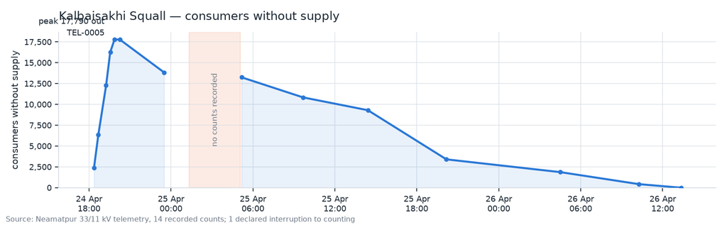

*Consumers without supply over the course of Kalbaisakhi Squall, peaking at 17,790 at 19:52 on 24 April 2026 [TEL-0005].*

## 8. Consumer Contacts

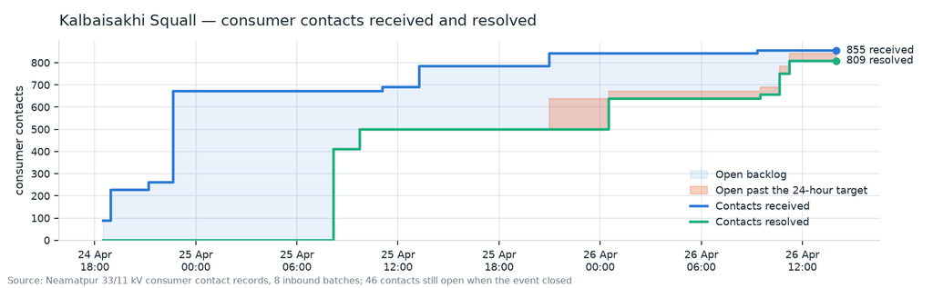

*Consumer contacts received and resolved over the course of Kalbaisakhi Squall, 855 received in total. 46 contacts were still open when the event closed.*

## 9. Lessons Learned

### Raised by this event

LL-A1 — Mutual-aid gang mobilisation times are not captured. Two mutual-aid gangs from the Durgapur circle worked the event and both were released against a recorded time, but neither carries a mobilisation time, so mutual-aid gang-hours cannot be computed from the records. Owner: Distribution Operations, Neamatpur Section. [CRW-0006, CRW-0008]. LL-A2 — Time to first consumer notification exceeded the two-hour target. The first outage was recorded at 18:22 and the first consumer notification was issued at 20:35, an interval of 2 hours 13 minutes against a two-hour internal target. Owner: Consumer Services Wing. [TEL-0001, COM-0003]. LL-A3 — Outage management system link was lost with no fallback capture. The link to the Neamatpur RTU was unavailable for 3 hours 45 minutes and no manual consumer counts were taken during the gap, leaving a hole in the restoration curve that cannot be reconstructed. Owner: SCADA and IT Wing. [TEL-0008, TEL-0009]. LL-A4 — A consumer-reported pole was never inspected. A consumer reported a tree trunk resting against a pole at Mohishila Bazaar on the first evening. No gang was assigned, the report was still unresolved when the event closed, and the pole has never been confirmed either damaged or sound. Owner: Distribution Operations, Neamatpur Section. [DMG-0006, COM-0005].